# xwMOOC 모형

dplyr + $H_2 O$ AutoML

2018-08-03

# 1 캐글 백오더 데이터와 준비

캐글 “백오더(backorder)” 데이터는 **went_on_backorder**인지 예측하는 문제다.

- sku - Random ID for the product
- national_inv - Current inventory level for the part
- lead_time - Transit time for product (if available)
- in_transit_qty - Amount of product in transit from source
- forecast_3_month - Forecast sales for the next 3 months
- forecast_6_month - Forecast sales for the next 6 months
- forecast_9_month - Forecast sales for the next 9 months
- sales_1_month - Sales quantity for the prior 1 month time period
- sales_3_month - Sales quantity for the prior 3 month time period
- sales_6_month - Sales quantity for the prior 6 month time period
- sales_9_month - Sales quantity for the prior 9 month time period
- min_bank - Minimum recommend amount to stock
- potential_issue - Source issue for part identified
- pieces_past_due - Parts overdue from source
- perf_6_month_avg - Source performance for prior 6 month period
- perf_12_month_avg - Source performance for prior 12 month period
- local_bo_qty - Amount of stock orders overdue
- deck_risk - Part risk flag
- oe_constraint - Part risk flag
- ppap_risk - Part risk flag
- stop_auto_buy - Part risk flag
- rev_stop - Part risk flag
- **went_on_backorder** - Product actually went on backorder. This is the target value.

백오더 예측을 위해서 다음 팩키지가 필요하다.

- `tidyverse`: dplyr, tidyr, ggplot 등
- `unbalanced`: 백오더가 매우 드문 상황이라 데이터 불균형 문제를 해결하기 위해서 `ubSMOTE()` 함수를 사용한다.
- `h2o`: 기계학습 모형 개발에 사용되는 최신 알고리즘

# 2 `dplyr`과 $H_2O$

## 2.1 데이터

`[캐글 Product Backorder 데이터](https://github.com/rodrigosantis1/backorder_prediction/blob/master/data/kaggle/kaggle.rar)`를 다운로드 받아 데이터 정제과정을 거친다. 결측값처리와 문자형 변수를 숫자형으로 변환시키는 것이 포함된다.

```r
# 0. 환경설정 -----
library(tidyverse)
library(tidyquant)
library(janitor)
library(caret)
library(h2o)
library(unbalanced)

# 1. 데이터 -----
## 1.1. 데이터 가져오기 -----
train_dat    <- read_csv("data/Kaggle_Training_Dataset_v2.csv")
test_dat     <- read_csv("data/Kaggle_Test_Dataset_v2.csv")

## 1.2. 데이터 정제과정 -----

clean_data <- function(df) {
    clean_df <- df %>%
        clean_names() %>%
        remove_empty(c("rows", "cols")) %>%
        select(-sku) %>%
        mutate_if(is.character, .funs = function(x) ifelse(x == "Yes", 1, 0)) %>%
        mutate(went_on_backorder = as.factor(went_on_backorder)) %>%
        mutate(perf_6_month_avg = ifelse(perf_6_month_avg == -99, NA, lead_time)) %>%
        mutate(perf_6_month_avg = randomForest::na.roughfix(perf_6_month_avg)) %>%
        mutate(lead_time = ifelse(lead_time == -99, NA, lead_time)) %>%
        mutate(lead_time = randomForest::na.roughfix(lead_time)) %>%
        mutate(perf_12_month_avg = ifelse(perf_12_month_avg == -99, NA, lead_time)) %>%
        mutate(perf_12_month_avg = randomForest::na.roughfix(perf_12_month_avg))

    return(clean_df)
}

train_dat <- clean_data(train_dat)
test_df <- clean_data(test_dat)
```

## 2.2 클래스 불균형 문제

백오더 문제가 발생되는 사례가 상대적으로 희귀하기 때문에 예측모형 성능향상을 위해서 `SMOTE` 방법을 통해 클래스 불균형 문제를 보정한다.

- `perc.over = 200`: 과표본 추출(Oversampling) 비율로 5개의 희귀 백오더 관측점이 있다면 이를 200%해서 10개를 생성시킨다.
- `perc.under = 200`: 희귀 관측점이 아니라 다수를 점하는 관측점에 대한 것으로 SMOTE 과정을 통해서 10개가 생성되었다면, 200% 즉, 20개 표본이 추출된다.
- `k = 5`: 새로운 관측점을 생성할 때 참조하는 인점 관측점 숫자를 지정한다.

```r
## 1.3. 데이터 분할 -----
idx <- createDataPartition(train_dat$went_on_backorder,
                           p = 0.85, list = FALSE, times = 1)

train_df <- train_dat[ idx,]
valid_df  <- train_dat[-idx,]

## 1.4. 분균형 데이터문제 해결: SMOTE -----
input  <- train_df %>% select(-went_on_backorder)
output <- train_df$went_on_backorder
train_balanced <- ubSMOTE(input, output, perc.over = 200, perc.under = 200, k = 5)

train_df <- bind_cols(as.tibble(train_balanced$X), tibble(went_on_backorder = train_balanced$Y))

train_df %>% tabyl(went_on_backorder)
```

```
 went_on_backorder     n   percent
                 0 38400 0.5714286
                 1 28800 0.4285714
```

## 2.3 모형적합과 성능

$H_2O$ AutoML 기계학습 모형을 자동으로 적합해서 최적의 모형을 만들어 낸다. `h2o.performance()` 함수로 최적 모형에 대한 성능을 시각화한다.

```r
# 2. H2O 자동 기계학습(AutoML) -----
## 2.1. 데이터프레임 --> H2O 데이터프레임 변환
h2o.init()
```

```
 Connection successful!

R is connected to the H2O cluster:
    H2O cluster uptime:         51 minutes 10 seconds
    H2O cluster timezone:       Asia/Seoul
    H2O data parsing timezone:  UTC
    H2O cluster version:        3.20.0.2
    H2O cluster version age:    1 month and 18 days
    H2O cluster name:           H2O_started_from_R_victorlee_iad648
    H2O cluster total nodes:    1
    H2O cluster total memory:   3.31 GB
    H2O cluster total cores:    4
    H2O cluster allowed cores:  4
    H2O cluster healthy:        TRUE
    H2O Connection ip:          localhost
    H2O Connection port:        54321
    H2O Connection proxy:       NA
    H2O Internal Security:      FALSE
    H2O API Extensions:         Algos, AutoML, Core V3, Core V4
    R Version:                  R version 3.5.0 (2018-04-23)
```

```r
h2o.no_progress()

train_h2o <- as.h2o(train_df)
valid_h2o <- as.h2o(valid_df)
test_h2o  <- as.h2o(test_df)

## 2.2. 모형 공식 설정
y <- "went_on_backorder"
x <- setdiff(names(train_h2o), y)

## 2.3. 자동 기계학습
backorder_aml <- h2o.automl(
    x = x,
    y = y,
    training_frame    = train_h2o,
    validation_frame  = valid_h2o,
    leaderboard_frame = test_h2o,
    max_runtime_secs  = 45
)

backorder_lb <- backorder_aml@leader

## 2.4. 예측모형 성능평가
perf_h2o <- h2o.performance(backorder_lb, newdata = test_h2o)

h2o.auc(perf_h2o)
```

```
[1] 0.9131974
```

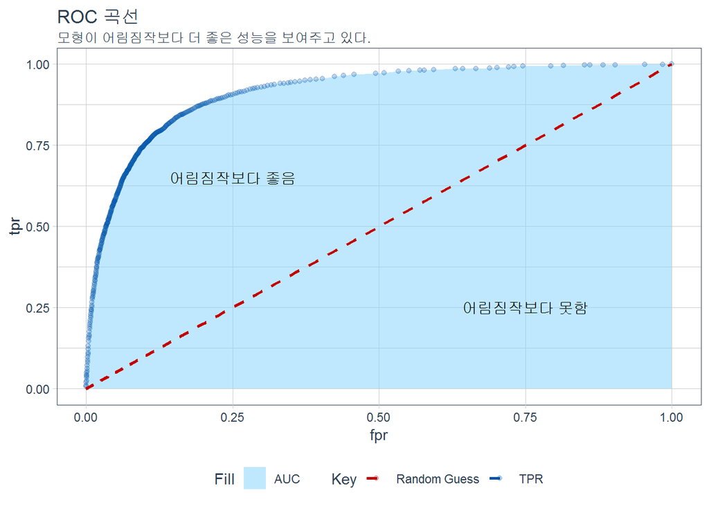

```r
left_join(h2o.tpr(perf_h2o), h2o.fpr(perf_h2o)) %>%
    mutate(random_guess = fpr) %>%
    select(-threshold) %>%
    ggplot(aes(x = fpr)) +
    geom_area(aes(y = tpr, fill = "AUC"), alpha = 0.5) +
    geom_point(aes(y = tpr, color = "TPR"), alpha = 0.25) +
    geom_line(aes(y = random_guess, color = "Random Guess"), size = 1, linetype = 2) +
    theme_tq(base_family = "NanumGothic") +
    scale_color_manual(
        name = "Key",
        values = c("TPR" = palette_dark()[[1]],
                   "Random Guess" = palette_dark()[[2]])
    ) +
    scale_fill_manual(name = "Fill", values = c("AUC" = palette_dark()[[5]])) +
    labs(title = "ROC 곡선",
         subtitle = "모형이 어림짐작보다 더 좋은 성능을 보여주고 있다.") +
    annotate("text", x = 0.25, y = 0.65, label = "어림짐작보다 좋음") +
    annotate("text", x = 0.75, y = 0.25, label = "어림짐작보다 못함")
```

## 2.4 백오더 예측

`test_h2o` 시험데이터로 백오더 가능성을 예측해본다. 백오더 예측확률이 제시되면 의사결정을 위한 컷오프를 설정해야 되는데 `perf_h2o@metrics$max_criteria_and_metric_scores` 곳에 `F1`을 비롯한 의사결정을 위한 지표가 모두 저장되어 있다.

```r
## 2.5. 백오더 예측

pred_h2o <- h2o.predict(backorder_lb, newdata = test_h2o)
pred_h2o %>% tbl_df
```

```
# A tibble: 242,075 x 3
   predict    p0     p1
   <fct>   <dbl>  <dbl>
 1 0       0.989 0.0108
 2 0       0.978 0.0221
 3 0       0.984 0.0165
 4 0       0.980 0.0203
 5 0       0.981 0.0194
 6 0       0.981 0.0191
 7 0       0.979 0.0213
 8 0       0.989 0.0110
 9 0       0.989 0.0109
10 0       0.981 0.0194
# ... with 242,065 more rows
```

```r
## 2.5. 컷오프 설정

perf_h2o@metrics$max_criteria_and_metric_scores %>% tbl_df %>%
    DT::datatable()
```

|  | metric | threshold | value | idx |
| --- | --- | --- | --- | --- |
| 1 | max f1 | 0.803105876851917 | 0.252484357747516 | 59 |
| 2 | max f2 | 0.71820126177753 | 0.332096474953618 | 84 |
| 3 | max f0point5 | 0.907011426725873 | 0.238478027867095 | 25 |
| 4 | max accuracy | 0.989306030343023 | 0.9888670866467 | 0 |
| 5 | max precision | 0.989306030343023 | 0.414634146341463 | 0 |
| 6 | max recall | 0.0101848013761762 | 1 | 399 |
| 7 | max specificity | 0.989306030343023 | 0.999899743929286 | 0 |
| 8 | max absolute_mcc | 0.790174044049397 | 0.258678918583228 | 63 |
| 9 | max min_per_class_accuracy | 0.0905619198165367 | 0.840396512759674 | 306 |
| 10 | max mean_per_class_accuracy | 0.088981906818678 | 0.84108089813277 | 307 |